# RareQ for scRNA Data

Last edited: November 16, 2025

**RareQ** is a network-propagation-based algorithm designed to identify both **major and rare cell populations** across diverse modalities, including RNA, ADT, ATAC, and spatial data. It operates on the **k-nearest neighbor (kNN)** graph, quantifying local topological structure via a **neighborhood connectivity metric (Q)**.

This tutorial demonstrates the use of **RareQ** on a standard **single-cell RNA-seq dataset**.

## Load the data

```r
library(Seurat)
library(RareQ)    # core method for rare-cell detection
library(ggplot2)

# Read example data
# Please replace the path with your local "Tutorial_example" directory
obj = readRDS('Tutorial_example/data/Jurkat.RDS')
counts = obj@assays$RNA@counts
```

## Preprocess the scRNA-seq data

RareQ operates on the **kNN graph**, therefore standard preprocessing is required. We use **Seurat** for quality control (QC), normalization, highly variable gene (HVG) selection, scaling, PCA and kNN graph construction.

```r
# Create Seurat object
sc_object <- CreateSeuratObject(count=counts, project = "sc_object", min.cells = 3)

# Basic QC
sc_object$percent.mt <- PercentageFeatureSet(sc_object, pattern = "^MT-")
sc_object <- subset(sc_object, percent.mt<20)

# Normalize, find HVGs and scale data
sc_object <- NormalizeData(sc_object)
sc_object <- FindVariableFeatures(sc_object, nfeatures=2000)
sc_object <- ScaleData(sc_object)

# Dimensionality reduction (50 PCs recommended to retain rare-cell structure)
sc_object <- RunPCA(sc_object, npcs=50)
sc_object <- RunUMAP(sc_object, dims=1:50)

# Build the kNN graph
sc_object <- FindNeighbors(object = sc_object,
                           k.param = 20,              # k = 20 typical in scRNA workflows
                           compute.SNN = FALSE,       # RareQ relies on directed kNN, not SNN
                           prune.SNN = 0,
                           reduction = "pca",
                           dims = 1:50,
                           force.recalc = FALSE,
                           return.neighbor = TRUE)    # returned neighbor list is essential for Q propagation
```

## Run RareQ

RareQ is executed using the `FindRare()` function with the processed Seurat object as input. The function returns the cluster label (major + rare clusters) for each cell.

```r
cluster <- FindRare(sc_object)
table(cluster)
```

```
## cluster
##   33 1125 1549
## 1526   14   16
```

The detailed steps of the RareQ algorithm involve the following:

- **Q values computing**

  RareQ defines a local mutual connectivity metric (**Q**) for each cell, quantifying how densely it connects within its k-1 nearest neighbors.

  Q ranges from 1⁄k to 1. High-Q cells represent locally dense micro-clusters suggestive of rare states.

  The `k` parameter controls the neighborhood size in computing Q values; smaller values enhance sensitivity to extremely rare populations (typically between 5 to the total nearest neighbors, default 6).
- **Q-guided label propagation**

  Each cell is initially treated as a singleton cluster.

  Cells iteratively adopt the label of the highest-Q neighbor until convergence or maximum number of iterations (`max_iter`) completing, ensuring that labels propagate outward from “waypoint” cells (local Q maxima).

  A subsequent majority-vote refinement stabilizes cluster boundaries.

  The `max_iter` parameter sets the maximum number of iterations for propagation if convergence is not reached (default 100).
- **Recursive cluster merging**

  Clusters with high average Q (> `Q_cut`) are retained as rare clusters.

  Remaining clusters are iteratively merged if
  - their internal connectivity improves upon merging (Q<sub>c</sub> of the merged cluster > each component);
  - the proportion of inter-cluster connections exceeds `ratio`.

  This prevents overfragmentation of major cell types.

  The `Q_cut` value specifies the minimum average Q for a cluster to be retained as a rare group (0.5-1.0, default 0.6).

  `Ratio` sets the threshold for merging clusters (default 0.2). When the proportion of a cluster’s connections with its neighboring clusters among its total connections is larger than this threshold, merge the two cell groups.

The function `ComputeQ()` can be used independently to visualize Q values for each cell. This is useful for understanding the landscape of rare vs major cell states.

```r
ComputeQ(
  sc_object,
  assay='RNA',
  k=6
)
```

Attach the identified cluster labels to Seurat metadata.

```r
sc_object$cluster = cluster
```

## Visualization

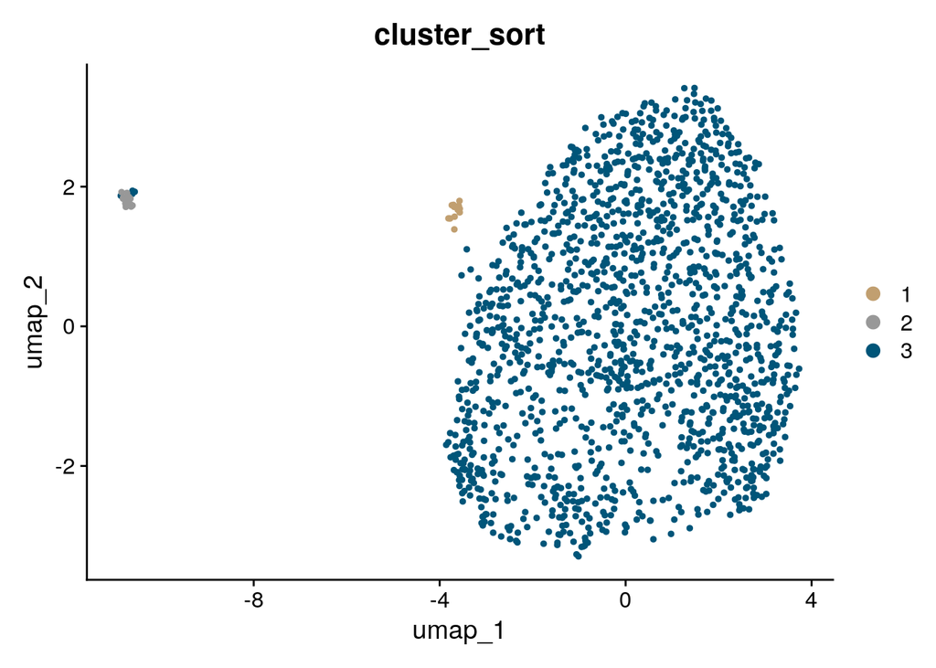

```r
# Label cluster according to cluster size
cluster.cnt <- sort(table(sc_object$cluster))
sc_object$cluster_sort = factor(as.character(sc_object$cluster), levels = names(cluster.cnt),
                                labels = 1:length(cluster.cnt), ordered = TRUE)

# Define color palette for visualization
cols <- c("#532C8A","#c19f70","#f9decf","#c9a997","#B51D8D","#9e6762","#3F84AA","#F397C0",
          "#C594BF","#DFCDE4","#eda450","#635547","#C72228","#EF4E22","#f77b59","#989898",
          "#7F6874","#8870ad","#65A83E","#EF5A9D","#647a4f","#FBBE92","#354E23","#139992",
          "#C3C388","#8EC792","#0F4A9C","#8DB5CE","#1A1A1A","#FACB12","#C9EBFB","#DABE99",
          "#ed8f84","#005579","#CDE088","#BBDCA8","#F6BFCB"
)

getPalette = colorRampPalette(cols[c(2,3,1,5,6,7,8,9,11,12,13,14,16,18,19,20,22,23,24,27,28,29,30,31,34)])

# UMAP visualization of RareQ-identified clusters
DimPlot(sc_object, group.by='cluster_sort') +
  scale_color_manual(values = getPalette(length(unique(sc_object$cluster_sort))))
```